# Homework 6

Jules Pellin

2026-06-01

# Question 1 - Scatter Plots

```r
library(tidyverse)
library(GGally)

# Read iris data from UCI repository
iris_df <- read.csv("https://archive.ics.uci.edu/ml/machine-learning-databases/iris/iris.data",
                    header = FALSE)

# Assign column names
colnames(iris_df) <- c("Sepal.Length", "Sepal.Width",
                        "Petal.Length", "Petal.Width", "Class")

# Examine the data
head(iris_df)
```

```
##   Sepal.Length Sepal.Width Petal.Length Petal.Width       Class
## 1          5.1         3.5          1.4         0.2 Iris-setosa
## 2          4.9         3.0          1.4         0.2 Iris-setosa
## 3          4.7         3.2          1.3         0.2 Iris-setosa
## 4          4.6         3.1          1.5         0.2 Iris-setosa
## 5          5.0         3.6          1.4         0.2 Iris-setosa
## 6          5.4         3.9          1.7         0.4 Iris-setosa
```

```r
str(iris_df)
```

```
## 'data.frame':    150 obs. of  5 variables:
##  $ Sepal.Length: num  5.1 4.9 4.7 4.6 5 5.4 4.6 5 4.4 4.9 ...
##  $ Sepal.Width : num  3.5 3 3.2 3.1 3.6 3.9 3.4 3.4 2.9 3.1 ...
##  $ Petal.Length: num  1.4 1.4 1.3 1.5 1.4 1.7 1.4 1.5 1.4 1.5 ...
##  $ Petal.Width : num  0.2 0.2 0.2 0.2 0.2 0.4 0.3 0.2 0.2 0.1 ...
##  $ Class       : chr  "Iris-setosa" "Iris-setosa" "Iris-setosa" "Iris-setosa" ...
```

```r
summary(iris_df)
```

```
##   Sepal.Length    Sepal.Width     Petal.Length    Petal.Width
##  Min.   :4.300   Min.   :2.000   Min.   :1.000   Min.   :0.100
##  1st Qu.:5.100   1st Qu.:2.800   1st Qu.:1.600   1st Qu.:0.300
##  Median :5.800   Median :3.000   Median :4.350   Median :1.300
##  Mean   :5.843   Mean   :3.054   Mean   :3.759   Mean   :1.199
##  3rd Qu.:6.400   3rd Qu.:3.300   3rd Qu.:5.100   3rd Qu.:1.800
##  Max.   :7.900   Max.   :4.400   Max.   :6.900   Max.   :2.500
##     Class
##  Length:150
##  Class :character
##  Mode  :character
##
##
##
```

## Q1a - Base R Scatter Plot: Sepal Width vs Sepal Length

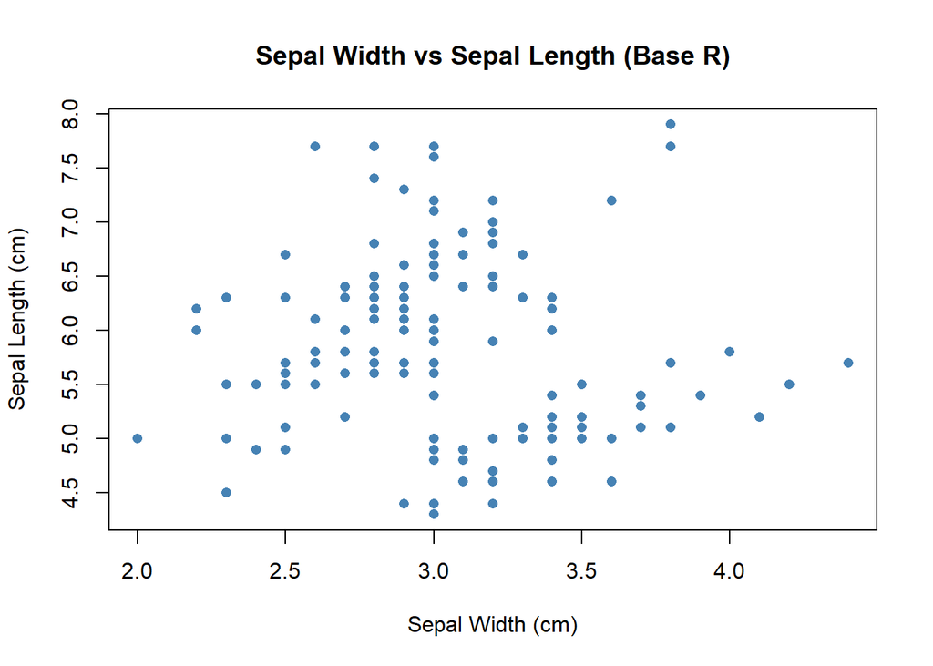

```r
plot(iris_df$Sepal.Width,
     iris_df$Sepal.Length,
     xlab = "Sepal Width (cm)",
     ylab = "Sepal Length (cm)",
     main = "Sepal Width vs Sepal Length (Base R)",
     pch  = 16,
     col  = "steelblue")
```

There’s no strong relationship between sepal width and sepal length when looking at all 150 observations together. The points are pretty scattered and the trend is slightly negative, which is a bit counterintuitive. This is actually a classic case where mixing all three species together masks what’s really going on, breaking it out by class would likely tell a clearer story.

## Q1b - ggplot2 Scatter Plot: Petal Width vs Sepal Width

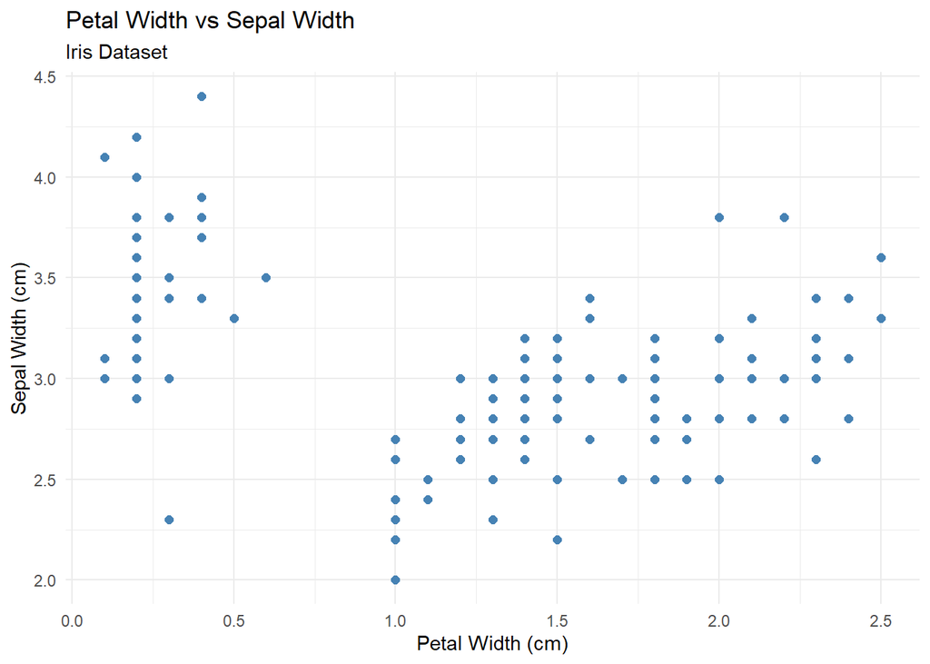

```r
ggplot(iris_df, aes(x = Petal.Width, y = Sepal.Width)) +
  geom_point(shape = 16, color = "steelblue", size = 2) +
  labs(title    = "Petal Width vs Sepal Width",
       subtitle = "Iris Dataset",
       x        = "Petal Width (cm)",
       y        = "Sepal Width (cm)") +
  theme_minimal()
```

There’s a weak negative relationship between petal width and sepal width, as petal width increases, sepal width tends to drop slightly. The cluster of points on the left with high sepal width values is almost certainly setosa, which has narrow petals but wider sepals. Without coloring by class it’s hard to see much structure here, which is exactly what Q1c fixes.

## Q1c - ggplot2 Scatter Plot: Petal Width vs Sepal Width by Class

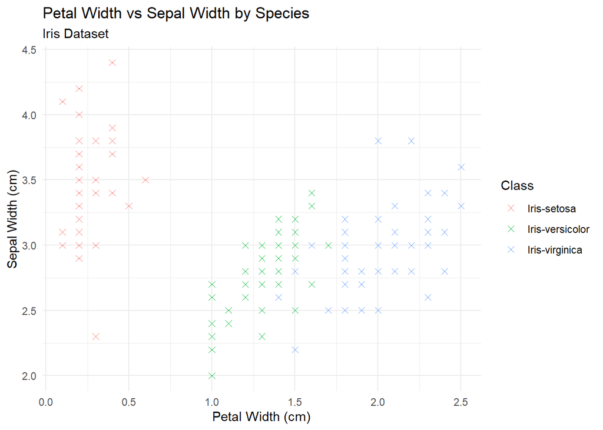

```r
ggplot(iris_df, aes(x = Petal.Width, y = Sepal.Width, color = Class)) +
  geom_point(shape = 4, size = 2) +
  labs(title    = "Petal Width vs Sepal Width by Species",
       subtitle = "Iris Dataset",
       x        = "Petal Width (cm)",
       y        = "Sepal Width (cm)") +
  theme_minimal()
```

Adding color makes everything click. Setosa is completely on its own on the left with narrow petals and wide sepals, while versicolor and virginica overlap a bit but are still fairly distinct. The negative trend from Q1b was basically just setosa dragging the left side up while the other two pulled the right side down.

# Question 2 - Scatter Plot Matrices

## Q2a - Base R pairs()

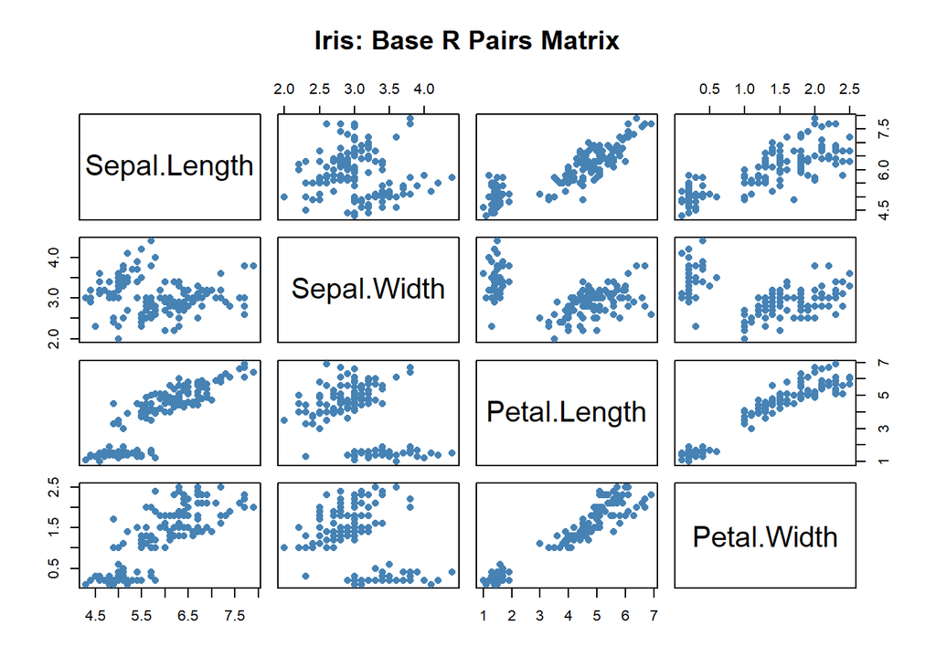

```r
pairs(iris_df[, 1:4],
      main   = "Iris: Base R Pairs Matrix",
      labels = colnames(iris_df[, 1:4]),
      pch    = 16,
      col    = "steelblue")
```

## Q2b - GGally ggpairs() with correlation coefficients

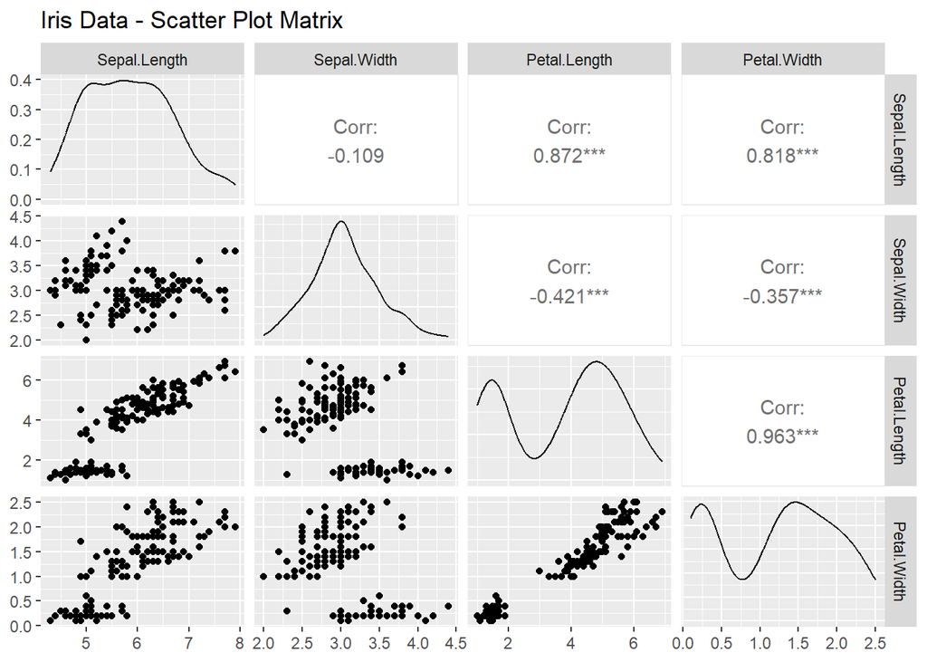

```r
ggpairs(iris_df[, 1:4],
        title = "Iris Data - Scatter Plot Matrix")
```

The numbers confirm what we suspected. Petal length and petal width have an almost perfect correlation at 0.963, they basically move together. Sepal length also connects well with both petal measurements, but sepal width is kind of the odd one out with weak or slightly negative correlations across the board. The bimodal density curves for petal measurements are a clear hint that the three species are pulling the data in different directions.

## Q2c - GGally ggpairs() colored by class

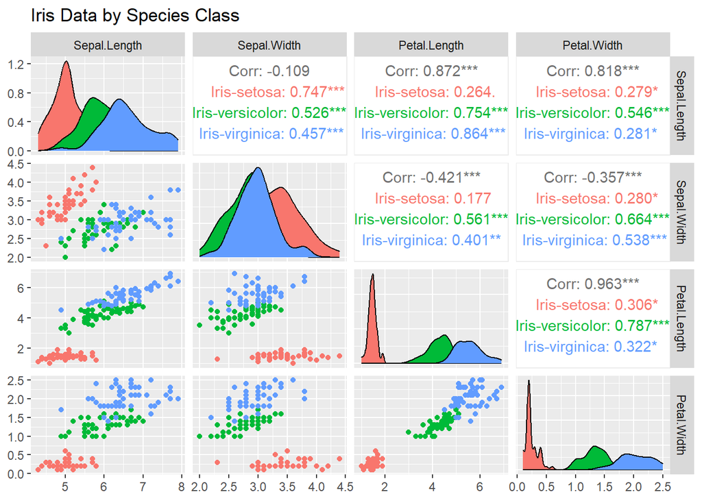

```r
ggpairs(iris_df,
        columns = 1:4,
        mapping = aes(color = Class),
        title   = "Iris Data by Species Class")
```

Breaking it out by species changes things quite a bit. The petal length vs petal width correlation drops from 0.963 overall to as low as 0.306 within setosa, versicolor is the only one holding a strong relationship at 0.787. Sepal width also flips from negative overall to positive within each species, which is a classic Simpson’s paradox situation. Setosa stays the most visually distinct cluster no matter which variables you look at.

# Question 3 - Choropleth Maps

```r
library(tidycensus)
library(sf)
library(tidyverse)
library(patchwork)

# Download median household income for WA counties
income_data <- get_acs(
  geography = "county",
  variables = "B19013_001",
  state     = "Washington",
  year      = 2024,
  geometry  = TRUE
)
```

[output not shown]

```r
# Download education variables (bachelor's + total pop)
education_data <- get_acs(
  geography = "county",
  variables = c("B15003_022", "B01003_001"),
  state     = "Washington",
  year      = 2024,
  geometry  = TRUE
)

# Download median home value
home_value_data <- get_acs(
  geography = "county",
  variables = "B25077_001",
  state     = "Washington",
  year      = 2024,
  geometry  = TRUE
)

cat("Income rows:", nrow(income_data), "\n")
```

```
## Income rows: 39
```

```r
cat("Education rows:", nrow(education_data), "\n")
```

```
## Education rows: 78
```

```r
cat("Home value rows:", nrow(home_value_data), "\n")
```

```
## Home value rows: 39
```

```r
# Education data needs special handling — sf blocks pivot_wider() directly
# Step 1: Save geometry separately
geometry_only <- education_data[, c("GEOID", "geometry")]

# Step 2: Drop geometry so pivot_wider() can run
education_no_geo <- st_drop_geometry(education_data)

# Step 3: Pivot to wide format
education_wide <- education_no_geo %>%
  pivot_wider(id_cols     = GEOID,
              names_from  = variable,
              values_from = estimate)

# Step 4: Rename columns
names(education_wide)[names(education_wide) == "B15003_022"] <- "bachelors"
names(education_wide)[names(education_wide) == "B01003_001"] <- "total_pop"

# Step 5: Rejoin geometry
complete_education <- left_join(geometry_only, education_wide, by = "GEOID") %>%
  st_as_sf()

# Step 6: Calculate percentage
complete_education <- complete_education %>%
  mutate(pct_bachelors = (bachelors / total_pop) * 100)

head(complete_education)
```

```
## Simple feature collection with 6 features and 4 fields
## Geometry type: MULTIPOLYGON
## Dimension:     XY
## Bounding box:  xmin: -123.2031 ymin: 45.83594 xmax: -118.9412 ymax: 47.40368
## Geodetic CRS:  NAD83
##   GEOID total_pop bachelors                       geometry pct_bachelors
## 1 53053    930319    124653 MULTIPOLYGON (((-122.6406 4...      13.39895
## 2 53053    930319    124653 MULTIPOLYGON (((-122.6406 4...      13.39895
## 3 53067    299067     50643 MULTIPOLYGON (((-123.2009 4...      16.93366
## 4 53067    299067     50643 MULTIPOLYGON (((-123.2009 4...      16.93366
## 5 53005    212905     28322 MULTIPOLYGON (((-119.8751 4...      13.30265
## 6 53005    212905     28322 MULTIPOLYGON (((-119.8751 4...      13.30265
```

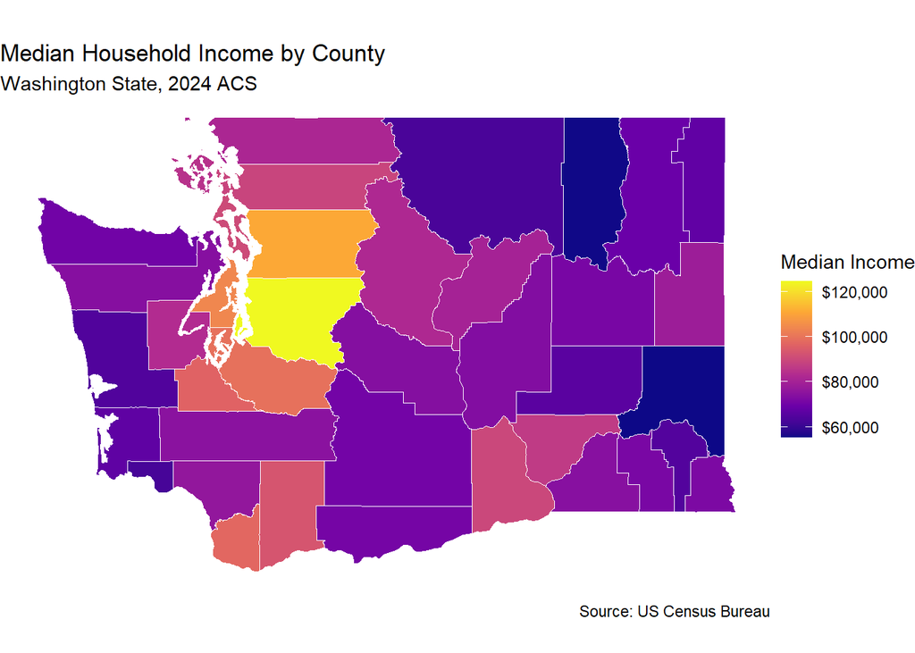

```r
# Map 1: Median Household Income
map_income <- ggplot(income_data) +
  geom_sf(aes(fill = estimate), color = "white", size = 0.3) +
  scale_fill_viridis_c(option = "plasma",
                       labels = scales::dollar_format()) +
  labs(title    = "Median Household Income by County",
       subtitle = "Washington State, 2024 ACS",
       fill     = "Median Income",
       caption  = "Source: US Census Bureau") +
  theme_void()

# Map 2: Bachelor's Degree Percentage
map_education <- ggplot(complete_education) +
  geom_sf(aes(fill = pct_bachelors), color = "white", size = 0.3) +
  scale_fill_viridis_c(option = "mako",
                       labels = function(x) paste0(round(x, 1), "%")) +
  labs(title    = "Adults with Bachelor's Degrees or Higher",
       subtitle = "Washington State, 2024 ACS",
       fill     = "% with Bachelor's",
       caption  = "Source: US Census Bureau") +
  theme_void()

# Map 3: Median Home Value
map_homevalue <- ggplot(home_value_data) +
  geom_sf(aes(fill = estimate), color = "white", size = 0.3) +
  scale_fill_viridis_c(option = "rocket",
                       labels = scales::dollar_format()) +
  labs(title    = "Median Home Value by County",
       subtitle = "Washington State, 2024 ACS",
       fill     = "Median Home Value",
       caption  = "Source: US Census Bureau") +
  theme_void()

# Display all three maps
map_income
```

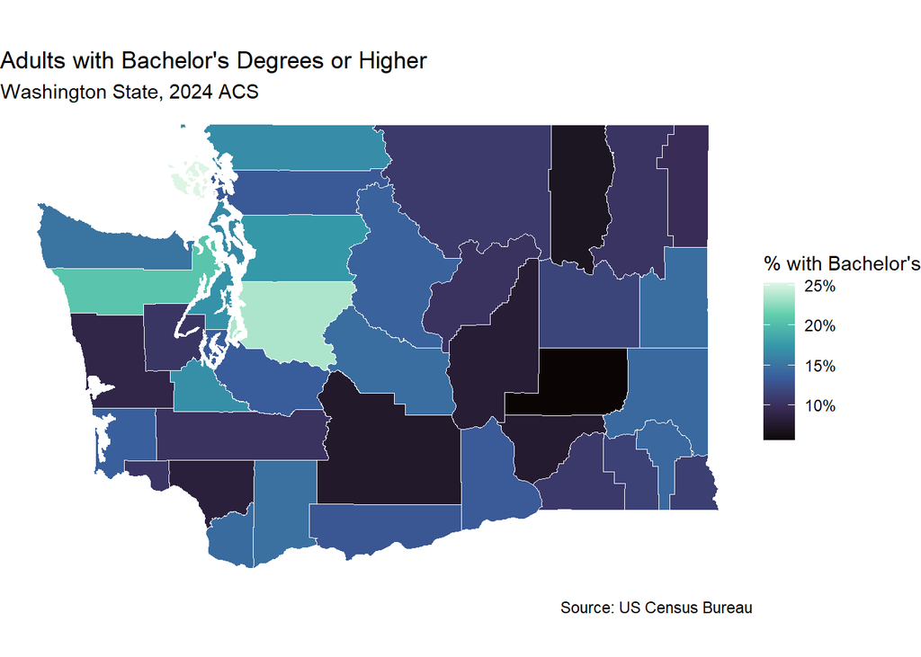

```r
map_education
```

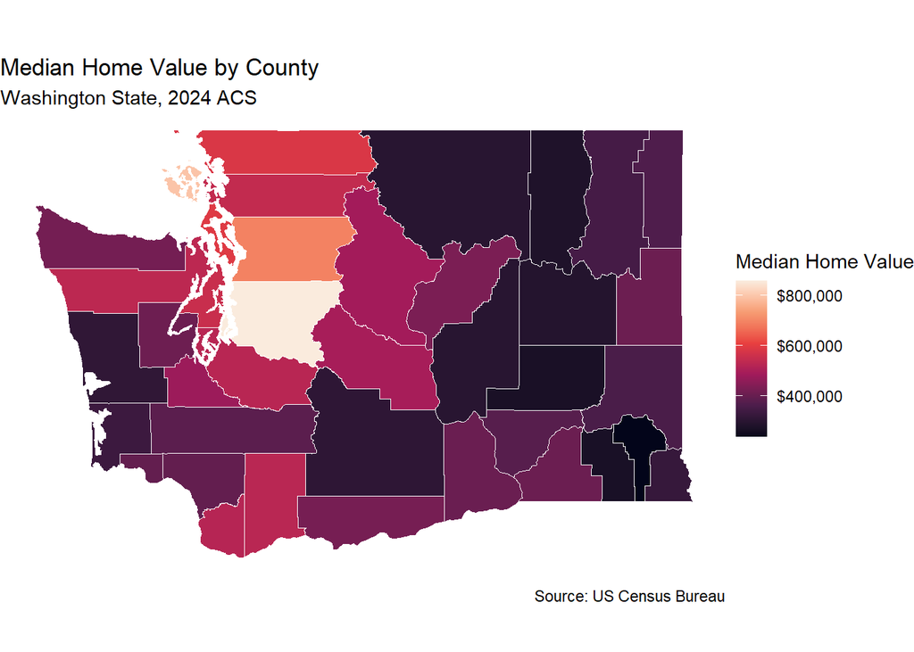

```r
map_homevalue
```

All three maps tell the same story: the Seattle area dominates across every measure. King County and its neighbors have the highest incomes, most college graduates, and home values pushing past $800,000. The eastern half of the state is noticeably lower across the board, which tracks with how rural and agricultural that region is.

Kittitas County lands in the middle on all three maps, which makes sense for a college town. CWU brings in students and faculty but also a lot of lower-income residents, keeping the averages moderate. Home values are mid-range but have probably been creeping up as remote workers from Seattle look for something more affordable within driving distance.